# R 중급 통계분석 4일차 (1)

# Why `ggplot2`?

## ggplot2장점

- 일관된 grammar of graphics (Wilkinson, 2005)
- 높은 수준의 그림 수준
- 매우 유연한 표현
- 테마를 이용한 그림 표현 변경
- 성숙하고 완전한 그래픽 시스템
- 많은 사용자들이 시각화에 이용

ggplot2로 할 수 없는 일

- 3차원 그래픽 (rgl 패키지 참조)
- 그래프 이론 유형 그래프 (노드/엣지 레이아웃; igraph 패키지)
- 대화식 그래픽 (ggvis 패키지 참조)

## 예제를 이용한 시각화

```r
housing <- read.csv("F:/work/2022/1. 발표/R 시각화 (통계교육원)/day2/landdata-states.csv")
head(housing)
```

```
##   State region    Date Home.Value Structure.Cost Land.Value Land.Share..Pct.
## 1    AK   West 2010.25     224952         160599      64352             28.6
## 2    AK   West 2010.50     225511         160252      65259             28.9
## 3    AK   West 2009.75     225820         163791      62029             27.5
## 4    AK   West 2010.00     224994         161787      63207             28.1
## 5    AK   West 2008.00     234590         155400      79190             33.8
## 6    AK   West 2008.25     233714         157458      76256             32.6
##   Home.Price.Index Land.Price.Index Year Qrtr
## 1            1.481            1.552 2010    1
## 2            1.484            1.576 2010    2
## 3            1.486            1.494 2009    3
## 4            1.481            1.524 2009    4
## 5            1.544            1.885 2007    4
## 6            1.538            1.817 2008    1
```

기본 그래픽을 이용한 히스토그램

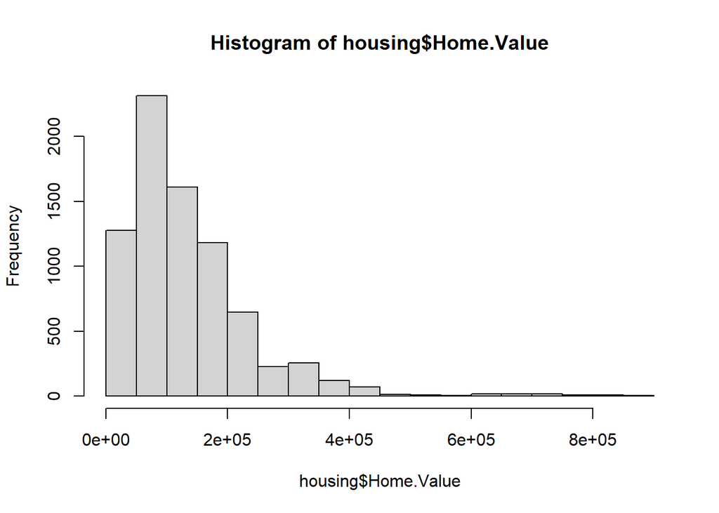

```r
hist(housing$Home.Value)
```

`ggplot2` 히스토그램의 예

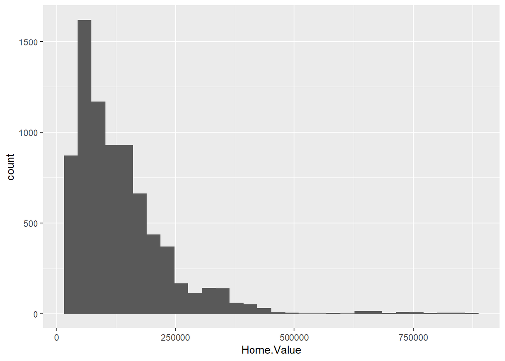

```r
library(ggplot2)
ggplot(data=housing, aes(x = Home.Value)) +
  geom_histogram()
```

plot을 이용한 자료의 시각화

```r
library(dplyr)
```

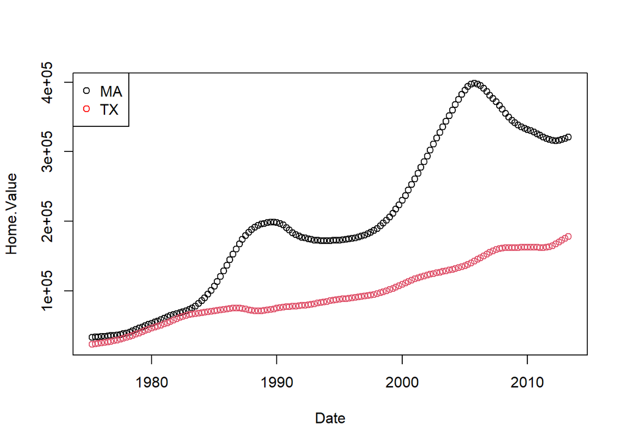

```r
plot(Home.Value ~ Date,
     col = factor(State),
     data = filter(housing, State %in% c("MA", "TX")))
legend("topleft",
       legend = c("MA", "TX"),
       col = c("black", "red"),
       pch = 1)
```

`ggplot2` 를 이용한 시각화

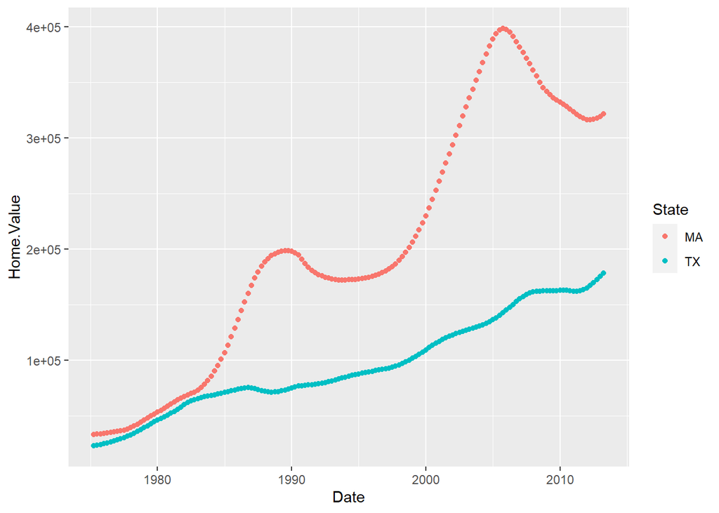

```r
ggplot(filter(housing, State %in% c("MA", "TX")),
       aes(x=Date,
           y=Home.Value,
           color=State))+
  geom_point()
```

## Aesthetic Mapping

ggplot의 aes는 “그림에서 할 수 있는 것들”을 의미한다.

- position (x and y axes)
- color
- fill
- shape
- linetype
- size

산점도의 경우 아래와 같이 시각화 된다.

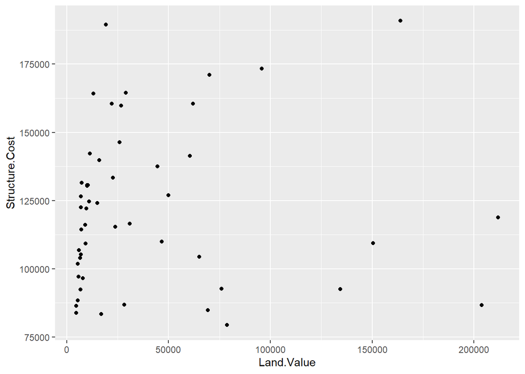

```r
hp2001Q1 <- filter(housing, Date == 2001.25)
ggplot(hp2001Q1,
       aes(y = Structure.Cost, x = Land.Value)) +
  geom_point()
```

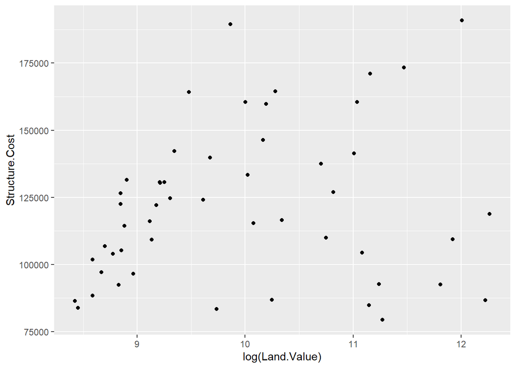

```r
ggplot(hp2001Q1,
       aes(y = Structure.Cost, x = log(Land.Value))) +
  geom_point()
```

예측선을 추가시키고 싶다면… + geom_line을 이용해서 선을 추가시킬 수 있다.

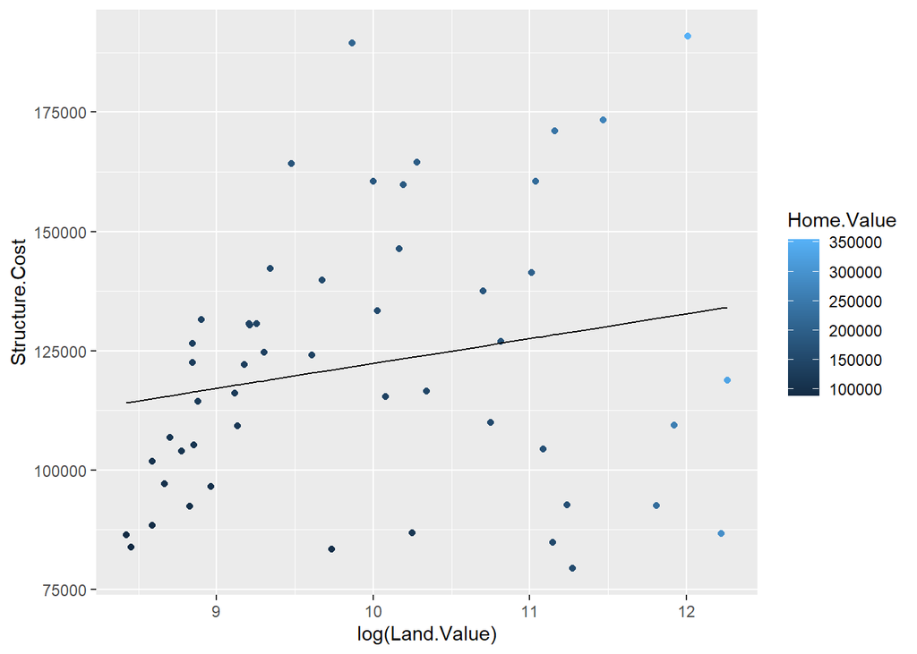

```r
hp2001Q1$pred.SC <- predict(lm(Structure.Cost ~ log(Land.Value), data = hp2001Q1))

p1 <- ggplot(hp2001Q1, aes(x = log(Land.Value), y = Structure.Cost))

p1 + geom_point(aes(color = Home.Value)) +
  geom_line(aes(y = pred.SC))
```

부드러운 선을 추가시키고 싶다면?? geom_smooth()를 추가시키자.

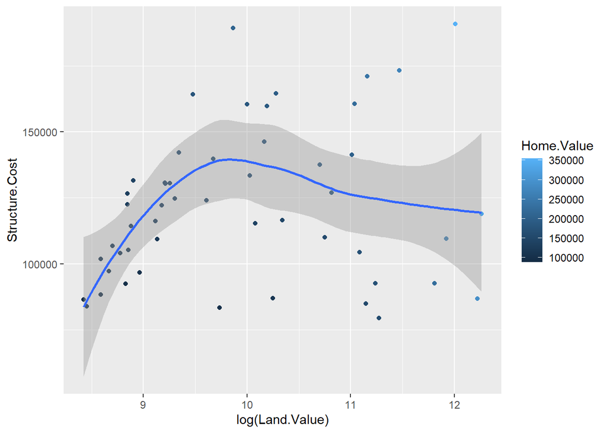

```r
 p1 +
  geom_point(aes(color = Home.Value)) +
  geom_smooth()
```

텍스트를 넣고 싶다면 geom_text를 이용하자.

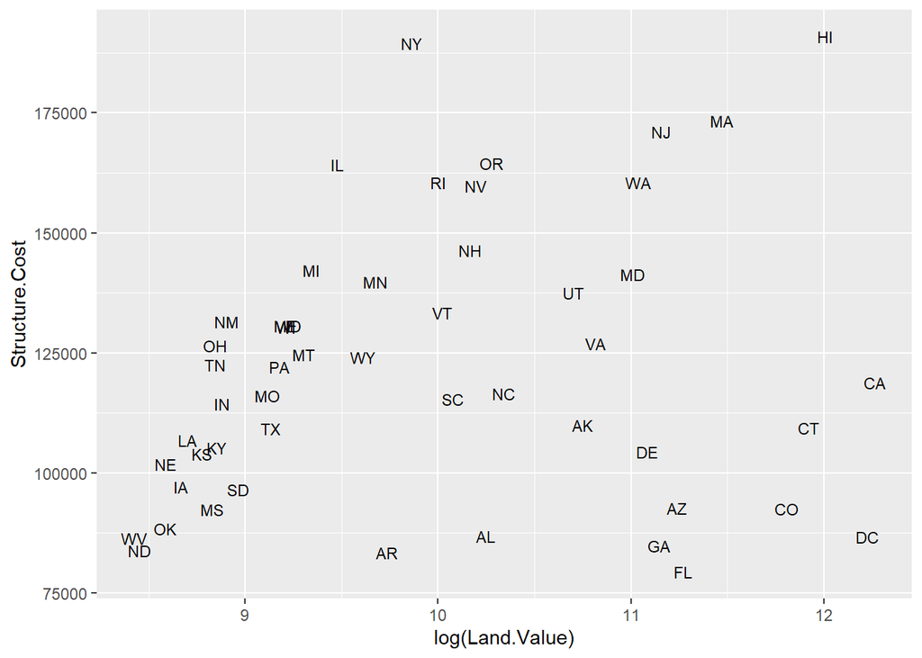

```r
p1 +
  geom_text(aes(label=State), size = 3)
```

색과 모양을 이용한 다양한 자료 표현

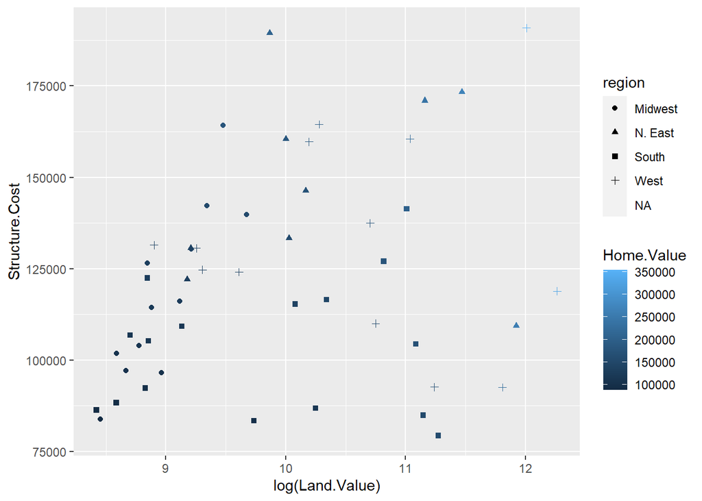

```r
p1 +
  geom_point(aes(color=Home.Value, shape = region))
```